# What Makes a Good Video Game

## Introduction

Video games are one of the most popular past times today. The first form of video games weren't even for entertainment purposes, they were for military. Over time, with the advances in technology and the growing popularity around gaming, video games started to become more creative and complex. one of the most notable events were the coin based arcade machines. These were those huge single game machines in stores and restaurants that used quaters per play. Soon, the gaming industry was brought to people's homes with consoles. These early forms of consoles laid the foundation for companies like Sony, Nintendo, Microsoft to build what are some of the most popular consoles in the world. But gaming is not just limited to consoles. PC Gaming is some thing that also became popular, starting from built in games like chess to web games like Club Penguin. PC gaming today is arguably the most famous forms of gaming since have a PC means you can do other work besides gaming. In order for gaming companies to rake in the most profits, they need to understand the gaming population and make decisions with what's working. With all of these different platforms, genres, and other metrics, it begs the question: What makes a good video game?

## Data Collection

The first step in the data science pipeline is to collect data. For my needs I want to find a dataset of some of the best modern titles. I found a dataset from [Kaggle](https://www.kaggle.com/datasets/gregorut/videogamesales), which got infomation from [vgchartz](https://www.vgchartz.com/), of games that sold more than 100000 copies and contains some statistics on sales of those games. They have it nicely formated for use in the form of a csv file, directly available on their site. If you want, they also provided [code](https://github.com/GregorUT/vgchartzScrape/blob/master/vgchartzfull.py) that scrapes the data directly from vgchartz. This is a useful skill to have for data science because not all data will be nicely formated and given to you. And so it is worth checking out. Also, this dataset is a bit old, so some of the numbers may not be up to date, especially the closer you get to modern day. And because of the age, mobile games are not included in this dataset.

```python
import numpy as np
import pandas as pd

# load the csv file locally
vgsales = pd.read_csv('vgsales.csv')
```

```python
# here's the top 10 of video game sales
vgsales
```

|  | Rank | Name | Platform | Year | Genre | Publisher | NA_Sales | EU_Sales | JP_Sales | Other_Sales | Global_Sales |
| --- | --- | --- | --- | --- | --- | --- | --- | --- | --- | --- | --- |
| 0 | 1 | Wii Sports | Wii | 2006.0 | Sports | Nintendo | 41.49 | 29.02 | 3.77 | 8.46 | 82.74 |
| 1 | 2 | Super Mario Bros. | NES | 1985.0 | Platform | Nintendo | 29.08 | 3.58 | 6.81 | 0.77 | 40.24 |
| 2 | 3 | Mario Kart Wii | Wii | 2008.0 | Racing | Nintendo | 15.85 | 12.88 | 3.79 | 3.31 | 35.82 |
| 3 | 4 | Wii Sports Resort | Wii | 2009.0 | Sports | Nintendo | 15.75 | 11.01 | 3.28 | 2.96 | 33.00 |
| 4 | 5 | Pokemon Red/Pokemon Blue | GB | 1996.0 | Role-Playing | Nintendo | 11.27 | 8.89 | 10.22 | 1.00 | 31.37 |
| ... | ... | ... | ... | ... | ... | ... | ... | ... | ... | ... | ... |
| 16593 | 16596 | Woody Woodpecker in Crazy Castle 5 | GBA | 2002.0 | Platform | Kemco | 0.01 | 0.00 | 0.00 | 0.00 | 0.01 |
| 16594 | 16597 | Men in Black II: Alien Escape | GC | 2003.0 | Shooter | Infogrames | 0.01 | 0.00 | 0.00 | 0.00 | 0.01 |
| 16595 | 16598 | SCORE International Baja 1000: The Official Game | PS2 | 2008.0 | Racing | Activision | 0.00 | 0.00 | 0.00 | 0.00 | 0.01 |
| 16596 | 16599 | Know How 2 | DS | 2010.0 | Puzzle | 7G//AMES | 0.00 | 0.01 | 0.00 | 0.00 | 0.01 |
| 16597 | 16600 | Spirits & Spells | GBA | 2003.0 | Platform | Wanadoo | 0.01 | 0.00 | 0.00 | 0.00 | 0.01 |

16598 rows × 11 columns

A quick note on the data, all sales numbers are in millions.

## Data Processing

Now that we have the data, we should clean it up to make it more usable. First, is to address any missing data. Sales numbers for some games are missing in the sense that there was no reporting of sales numbers in that country. This was because of the game not being officially released in said country or countries. Which makes this kind of missing data, missing not at random. Because there are no official sales numbers, I am going to fill in those spots with zero because the amount of sales are officially zero.

```python
# replace missing sales values with zeros
vgsales['NA_Sales'] = vgsales['NA_Sales'].fillna(0)
vgsales['EU_Sales'] = vgsales['EU_Sales'].fillna(0)
vgsales['JP_Sales'] = vgsales['JP_Sales'].fillna(0)
vgsales['Other_Sales'] = vgsales['Other_Sales'].fillna(0)
vgsales['Global_Sales'] = vgsales['Global_Sales'].fillna(0)
```

Next would be to convert some of the numeric columns to be integers or floats since numbers are better analysis. Pandas has a useful function [to_numeric](https://pandas.pydata.org/docs/reference/api/pandas.to_numeric.html) that changes strings to integers or floats.

```python
# convert numerical columns to be numbers
vgsales['Rank'] = pd.to_numeric(vgsales['Rank'])
vgsales['Year'] = pd.to_numeric(vgsales['Year'])
vgsales['NA_Sales'] = pd.to_numeric(vgsales['NA_Sales'])
vgsales['EU_Sales'] = pd.to_numeric(vgsales['EU_Sales'])
vgsales['JP_Sales'] = pd.to_numeric(vgsales['JP_Sales'])
vgsales['Other_Sales'] = pd.to_numeric(vgsales['Other_Sales'])
vgsales['Global_Sales'] = pd.to_numeric(vgsales['Global_Sales'])
```

Some video game titles have missing release date years. A quick google search of the name of the game will show you the official release date. I updated my own copy of the dataset to reflect that, but if you were to download the data yourself, then you would have to manually update that yourself. Or you can cross reference it with another dataset to fill in the missing data.

## Exploratory Analysis and Data Visualization

Now that we have the data in a usable form, we can now use it in creating visualizations to see trends and patterns within the data. These will help provide insights on things that we might want to take a closer look at for maybe some further analysis. We'll utilize some data visualization libraries for this.

```python
import matplotlib.pyplot as plt
from matplotlib.pyplot import cm
import seaborn as sns
import warnings
warnings.filterwarnings("ignore")
```

One initial metric we want to look at is the number of sales for games released during a particular time. Maybe a region has something to do with sales. In order to do this, we need to group games by their release date.

```python
# group by year
data_by_year = vgsales.groupby(['Year']).sum()
# get the years for plot
print(data_by_year.index)
```

```
Float64Index([1980.0, 1981.0, 1982.0, 1983.0, 1984.0, 1985.0, 1986.0, 1987.0,
              1988.0, 1989.0, 1990.0, 1991.0, 1992.0, 1993.0, 1994.0, 1995.0,
              1996.0, 1997.0, 1998.0, 1999.0, 2000.0, 2001.0, 2002.0, 2003.0,
              2004.0, 2005.0, 2006.0, 2007.0, 2008.0, 2009.0, 2010.0, 2011.0,
              2012.0, 2013.0, 2014.0, 2015.0, 2016.0, 2017.0, 2020.0],
             dtype='float64', name='Year')
```

An important note is that the number of sales is the total since the time period, so you can think of the plot as the total sales for a game made in that time period.

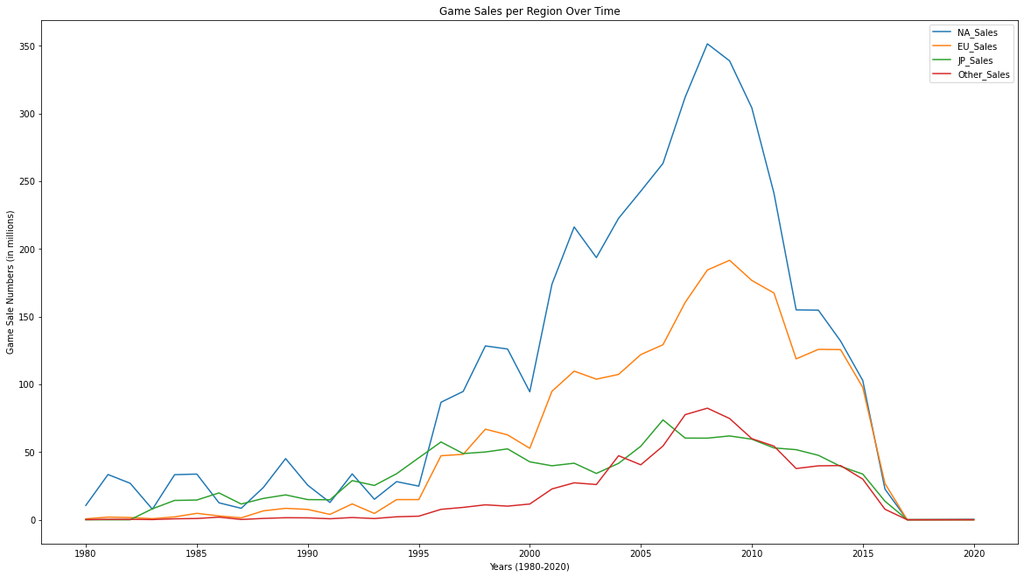

```python
plt.figure(figsize=(20, 11))
plt.title('Game Sales per Region Over Time')
plt.xlabel('Years (1980-2020)')
plt.ylabel('Game Sale Numbers (in millions)')

plt.plot(data_by_year.index, data_by_year['NA_Sales'], label='NA_Sales') # North America
plt.plot(data_by_year.index, data_by_year['EU_Sales'], label='EU_Sales') # Europe
plt.plot(data_by_year.index, data_by_year['JP_Sales'], label='JP_Sales') # Japan
plt.plot(data_by_year.index, data_by_year['Other_Sales'], label='Other_Sales')

plt.legend()
plt.show()
```

To see that, let's look at the top five games in global sales to see how they sales are distributed throughout regions. I'm going to use pie charts so you can see the proportions easier. And you can get a sense of the percentages for each compared to the global/total sales.

```python
top_ten = vgsales[['Name', 'NA_Sales', 'EU_Sales', 'JP_Sales']].head(5)
```

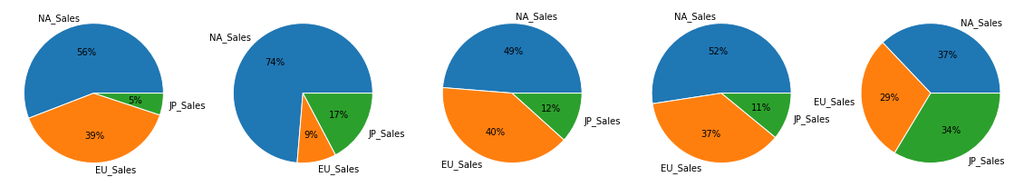

```python
fig, ax = plt.subplots(1,5, figsize=(20,4))
c = 0
for i in range(5):
    wedges = list(top_ten.iloc[i][1:4])
    labels = list(top_ten.columns[1:4])
    ax[i].pie(x = wedges, labels=labels, wedgeprops = { 'linewidth' : 1, 'edgecolor' : 'white' }, autopct = '%0.0f%%')
    c = c + 1

plt.show()
```

You can see that NA, North America, has the highest ratio when compared to the other two and EU usually has the second most. And you can see that EU sales and JP sales are not negligible, they hold a decent proportion. Now, we only looked at the top five games in global sales, but they have the most sales and therefore they hold the most weight in terms of raw numbers.

### What about Game Publishers?

An interesting metric would be which publishers make the top of the sales. We typically know the big names like Nintendo, Sega, Blizzard, EA, etc. but how do they perform when looking at each other. Since we have 579 different publishers, it would be too much to look at all of them at once, so we'll take a look at the top 2%, which is about 12 publishers.

```python
# there are this many unique game publishers in this dataset
print('There are different', len(vgsales['Publisher'].unique()), 'publishers.', sep=' ')
```

```
There are different 579 publishers.
```

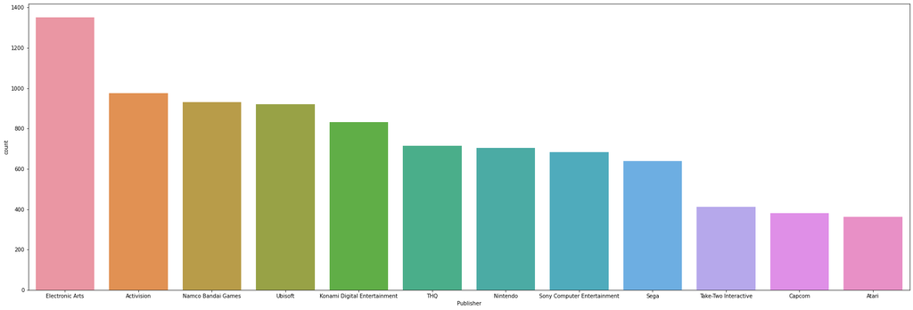

```python
plt.figure(figsize=(30,10))
# it would be impossible to show all 579, so we will look at the first 12
publishers_12 = list(pd.value_counts(vgsales['Publisher']).iloc[:12].index)
sns.countplot(x='Publisher', data=vgsales, order=publishers_12)
plt.show()
```

It seems that after the 9th publisher, Sega, there starts to be a significant dip in number of titles that make the list. The visual representation might be not a good exmaple based on the scale used, but the actual different is about 200 games. If you compare that to the number of total games of Take-Two Interactive, the 10th highest publisher, 200 games is over one third of their games. Which is a significant percentage when looked at the publisher individually.

But just looking at the number of titles doesn't take into account the amount of sales that those publishers made. It would be unfair to categorize a game that sold 1000000 copies to one that sold 100000 copies. Let's take a look of the number of total game sales for these 12 publishers. Then let's check the average sales for each game from each publisher.

```python
# make a deep copy of original data
vgsales_2 = vgsales.copy(deep=True)
publisher_globalsales_12 = vgsales_2.copy(deep=True)

publisher_globalsales_12 = publisher_globalsales_12[publisher_globalsales_12['Publisher'].isin(publishers_12)]
```

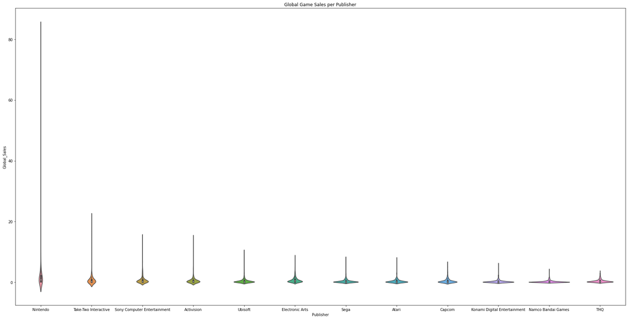

```python
plt.figure(figsize=(30,15))
# it would be impossible to show all 579, so we will look at the first 12
sns.violinplot(x='Publisher', y='Global_Sales', data=publisher_globalsales_12)
plt.title('Global Game Sales per Publisher')
plt.show()
```

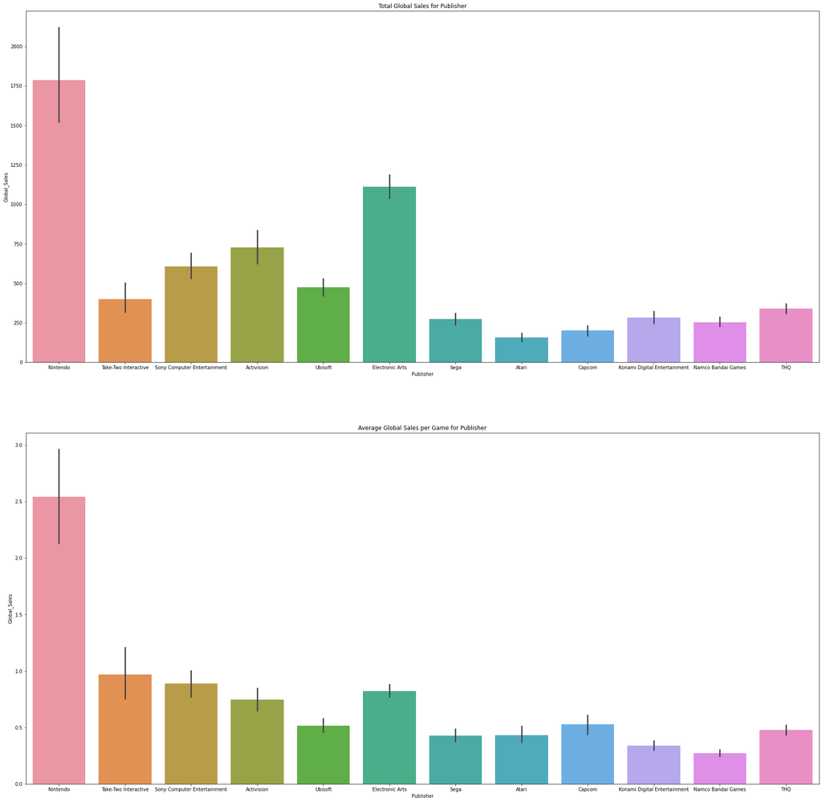

```python
fig, ax = plt.subplots(2,1, figsize=(30,30))
sns.barplot(x='Publisher', y='Global_Sales', data=publisher_globalsales_12, estimator=sum, ax=ax[0])
ax[0].set_title('Total Global Sales for Publisher')

# these show the average number of global game sales for each company
sns.barplot(x='Publisher', y='Global_Sales', data=publisher_globalsales_12, ax=ax[1])
ax[1].set_title('Average Global Sales per Game for Publisher')
plt.show()
```

Looking at the violinplot, it will be hard to see the distribution because of the outliers, but just looking at the ends of each will show you the mins and maxes that each publisher gets. You can see that all publishers have games that do relatively poorly, shown by the min, but the point of interest is the max of each. The max shows the games that had the most global sales for the publishers. And you can see that the further right of the publishers, they have games that don't nearly sell as well as some of those by the further left publishers. This can explain the heights of the top barplot, maybe those publishers just make more games and therefore have more games to make sales from. Additionaly, this could just be a trick because of a few games that sell really well, outlies can skew the data easily. Which is why consistency is another metric of importantance. To see that let's look at the bottom barplot. This barplot shows the average global sales for a game by the company and here we can see what the average game will be like. We see here that Electronic Arts, Capcom, and THQ have averages that are higher than the ones near it, but since they are further right on the list, it means they have games that don't have as high total global sales. But this metric shows how well a game sells on average, so you can expect a game from that company to sell that many. This is the idea of quality vs quantity. The quality of a game typically dictates the number of sales, but the quantity of games allows for additional sales. Some publishers release more games than others and that could be a reason why that publisher makes more sales, but some smaller publishers could be selling a game that competes with larger publishers in raw sales, but because of limitatons due to their smaller workforce, budget, etc., they can't release the same number of games to compete with overall. This is why looking at metrics besides the total number of sales is important.

### Does the Game's Genre Matter?

Just like with publishers, we can take a look at how a game's genre is related to game sales. There could a more general genre that sells more than a niche one. This could also show companies which game to develop because the population likes some more than others, and if they design a game that has a popular genre, then they are more likely to rack up sales.

```python
# different genres in vgsales
print(list(vgsales['Genre'].unique()))
```

```
['Sports', 'Platform', 'Racing', 'Role-Playing', 'Puzzle', 'Misc', 'Shooter', 'Simulation', 'Action', 'Fighting', 'Adventure', 'Strategy']
```

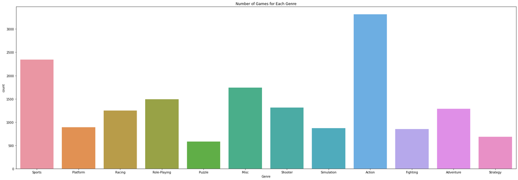

```python
plt.figure(figsize=(30,10))
# it would be impossible to show all 579, so we will look at the first 12
publishers_12 = list(pd.value_counts(vgsales['Publisher']).iloc[:12].index)
sns.countplot(x='Genre', data=vgsales)
plt.title('Number of Games for Each Genre')
plt.show()
```

So we can see that there is definitely more games of a particular genre than others. Here the two that jump out are the action and sports genres. Which if if think about makes sense, action is a very broad category that contains a lot of overlap with other game genres. Then there are sports games, a very family friendly game gnere, that most people have lying around in their collection. Again, instead of looking at just the number of games that fall under the genre (quantity), let's take a look at the sales for each genre (quality).

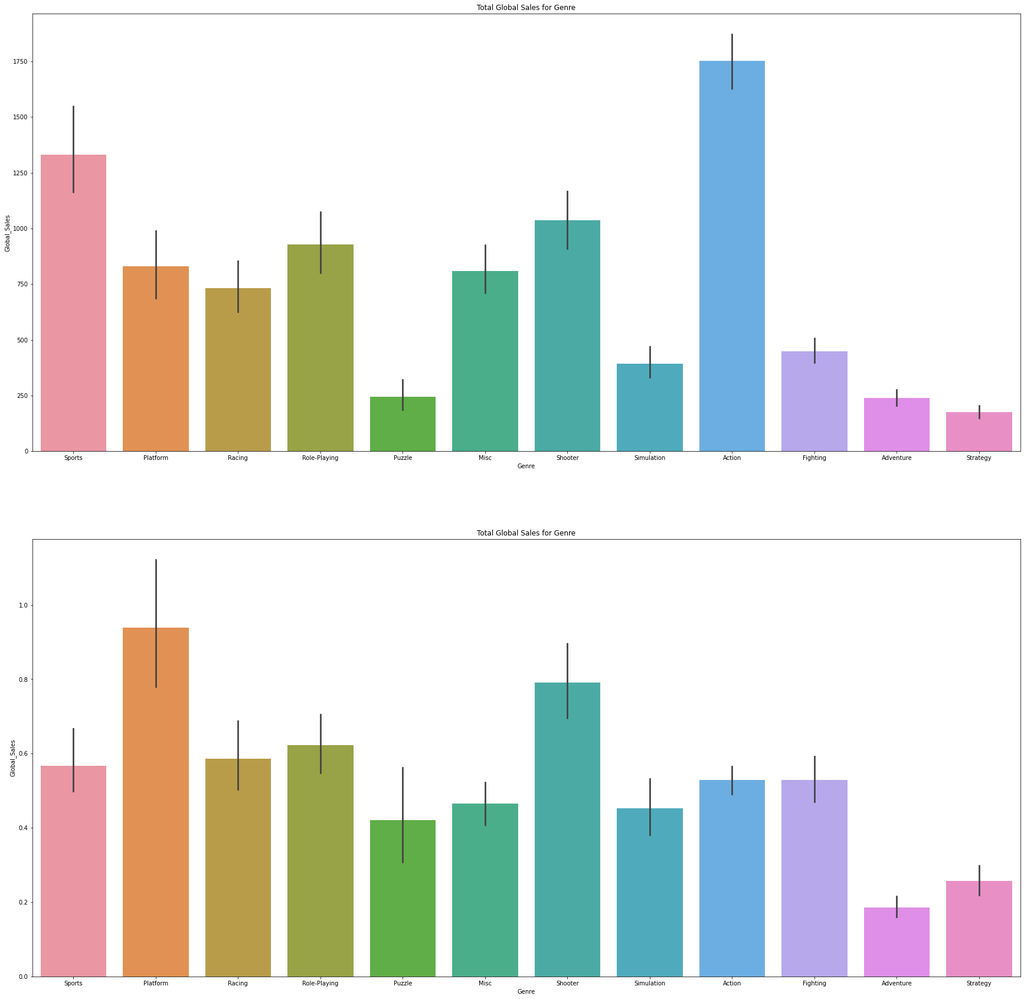

```python
fig, ax = plt.subplots(2,1, figsize=(30,30))
# barplot of total sales per genre
sns.barplot(x='Genre', y='Global_Sales', data=vgsales, estimator=sum, ax=ax[0])
ax[0].set_title('Total Global Sales for Genre')

# barplot of average sales per genre
sns.barplot(x='Genre', y='Global_Sales', data=vgsales, ax=ax[1])
ax[1].set_title('Total Global Sales for Genre')

plt.show()
```

In terms of raw sales, you can see that action and sports hold the top two spaces, the top barplot. And this goes back the idea of having more games means more opportunities for sales. Those two genres also had the most number of games. But if you were to look at the means of each genre, the botto barplot, you can see that the two genres with the highest average global sales are platformers and shooters. Action and sports are not even in the top four spots. You can think of this as showing the the average platformer or shooter is going to outperform action and sport games. And as a company you can't rely on making the best game.

### A Specific Example

Now with the growing popularity of gaming over the years, it would be interesting to see the change in sales for companies over the years, and see if any genres are more popular than before. This would be hard to show for all companies, but let's take a closer look at Nintendo, a company that has been in the industry for a long time, covers many different genres, and is still going strong to this day.

```python
# subset the data to just include Nintendo
nintendo = vgsales[vgsales['Publisher'] == 'Nintendo']

# what to visualize genres so seperate them
genre_names = list(vgsales['Genre'].unique())

genres = []

# get data for each genre
for genre in genre_names:
    genres.append(nintendo[nintendo['Genre'] == genre])
```

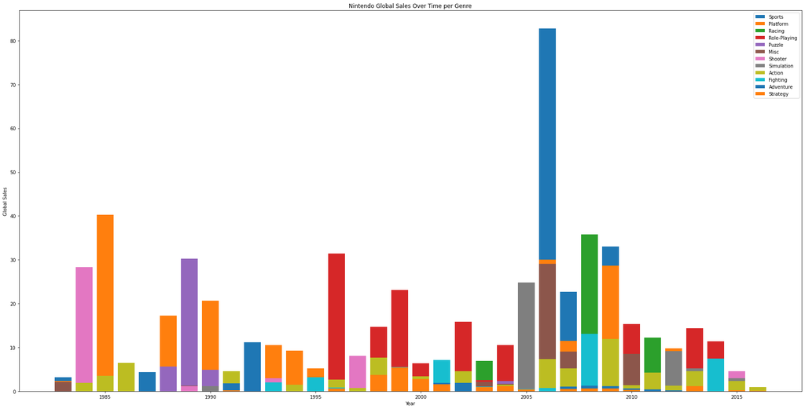

```python
plt.figure(figsize=(30,15))
plt.title('Nintendo Global Sales Over Time per Genre')
plt.xlabel('Year')
plt.ylabel('Global Sales')

i = 0
for genre in genres:
    plt.bar(genre['Year'], genre['Global_Sales'], label=genre_names[i])

    i = i + 1
plt.legend()
plt.show()
```

So looking at this you can see that the popular gaming genre from Nintendo was platformers early in its career. If you think back to old school Nintendo games, Super Mario was an iconic entry into the gaming industry and started the platformer craze. Then it moved to role-playing games, after the introduction of its popular in-game characters, Nintendo allowed plaers to play as their favorite characters. Then there was a time period of sports games, this was the introduction of the Wii, technology that used motion detection and allowed gamers to be more active, and then back to platformers. In the form of remakes of older but successful games, on their newer consoles.

## Hypothesis Testing Using Machine Learning

Now, I talked about these different metrics and tried to see some interesting trends. But let's switch gears and talk about how generalizable these finds are. Ideally, these findings in the sample we took can be applied to the population of the gaming industry. To do so, we are going to use [hypothesis testing](https://www.britannica.com/science/statistics/Hypothesis-testing). Basically, we have some kind of hypothesis about the relationship between variables, in this case the metadata of games, that we want to generalize to the population, the gaming industry. We only have a sample here that we ran our analysis on, but we want to see if there is actually a relationship in the actual population. To do so we need something called the null hypothesis, $H_0$, which is the idea that there is no relationship between those variables, or the observed relationship is caused by random error. And we want to reject, beyond reasonable doubt, the $H_0$ so we can accept our alternative hypotesis, $H_1$, or that there is a relationship between the variables.

**Assumptions of Hypothesis Testing**

1. The DV is measured on an interval scale
2. Participants are randomly selected
3. The distribution of the population is approximately normal

Looking back at the first plot of global sales vs. time, how can we be sure that this apparent relationship is not due to random chance. Random chance refers to things like our sample data was skewed. So let's say that our null hypothesis, $H_0$, is that there is no relationship between global sales and time. And our alternate hypothesis, $H_1$, is that there is a relationship. To start we need to set some kind of *predetermined* [alpha](https://methods.sagepub.com/reference/encyclopedia-of-survey-research-methods/n13.xml) value, $\alpha$, so that when we compare the computed [p-value](https://towardsdatascience.com/p-values-explained-by-data-scientist-f40a746cfc8) with it, we can decide if we reject the $H_0$. This avoids cherry picking numbers because if you first compute the p-value then you can always pick an alpha that is lower, and therefore you always reject the $H_0$.

For our alpha, we are going to use 0.05. This number is the current standard according to this [paper](https://www.ncbi.nlm.nih.gov/pmc/articles/PMC6314595/).

> $\alpha = 0.05$

Now we need to calculate the p-value.

### Using Regression

One kind of prediction model is to use something called [regression](https://www.seldon.io/machine-learning-regression-explained). Which is great at determining the relationship of independent variable(s) and a dependent variable. We can analyze this model's statistics to see if the p-value is lowerer or higher than the $\alpha$ described above. There are many [different models](https://www.analyticsvidhya.com/blog/2022/01/different-types-of-regression-models/) for regression, the simplest being linear regression. If you think back to your algebra class, you can think of it as a line of best fit. [Seaborn](https://seaborn.pydata.org/generated/seaborn.regplot.html) has a regression plot function that also shows you the data that the regression for a provided dataset, so let's take a look at that.

```python
# need to add a column for the years, since the grouping before made the year the index
data_by_year.insert(6, "Year", data_by_year.index, True)
```

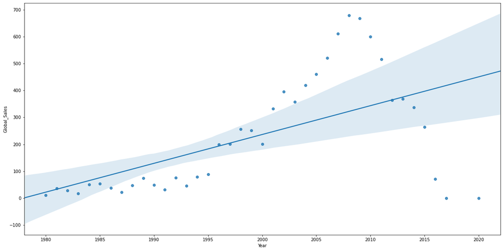

```python
plt.figure(figsize = (20, 10))
regr = sns.regplot(x='Year', y='Global_Sales', data=data_by_year, truncate=False)
plt.show()
```

Seeing the visual is nice, the line seems to be increasing. Which would signal that there is some positive linear relationship between global sales and time. But we are interested in the statistics of this, we want the p-value. There is a nice [function](https://docs.scipy.org/doc/scipy-0.14.0/reference/generated/scipy.stats.linregress.html) from the scipy library that gives you some important linear regression statistics.

```python
from scipy import stats
```

```python
slope, intercept, r_value, p_value, std_err = stats.linregress(data_by_year['Year'], data_by_year['Global_Sales'])
```

```python
print('Slope is: ', slope, sep='')
print('Intercept is: ', intercept, sep='')
print('r-value is: ', r_value, sep='')
print('p-value is: ', p_value, sep='')
```

```
Slope is: 10.70531709709055
Intercept is: -21174.314790781296
r-value is: 0.5794316898393971
p-value is: 0.00011099084731023857
```

So our linear regression model has a p-value of $0.00011099084731023857$. And our predetermined $\alpha$ is $0.05$

> $pvalue = 0.00011099084731023857 < \alpha = 0.05$

## Conclusion of Insights

So to wrap up what this tutorial was meant to show, we first wanted to find a topic that we code run data science on. This means that the topic needs some data on it and you want to explore what that data means. For this tutorial we chose the topic of video games, an extremely popular hobby with a large work force where there is a ton of data. So the first step we did was to actually gather some data. After a brief search, there was a precompiled dataset of sales for games. Then we had to process that dataset to fit our needs. This included handling any missing data and formatting it for categorical and statistical measures. Then came to part of exploration where we looked at interesting trends. This tutoral looked at global sales over time, the average game sale vs total game sales for publishers, and more. We also looked into a specific publisher, Nintendo, and looked at interesting metrics for a well-known company. You can think of this like a mini case study. We saw that with the change in technology over time, there was also a change of genre popularity and game creation. Then we wanted to prove there was a relationship of sales and time which was intially shown in the exploratory phase. We used hypothesis testing to compare measures of p-values and alpha values to see if there was any statistical evidence. We found that there was a relationship because our computed p-value, from using a linear regression, was lower than the industry standard alpha value.

I hope this tutorial taught you something and shed some light on one way you can use data science.